# Checking EPC datasets for Southampton

Data cleaning, outlier checks and coverage analysis

Ben Anderson

Last run at: 2020-11-12 13:24:35

# 1 Energy Performance Certificates (EPCs)

Apart from a few exempted buildings, a dwelling must have an EPC when constructed, sold or let. This means that over time we will have an EPC for an increasing number of properties and we should *already* have EPCs for all rented properties.

EPCs are not necessarily up to date. For example if a property has not been sold or let since a major upgrade, the effects of that upgrade may not be visible in the data.

Further reading:

- https://epc.opendatacommunities.org/docs/guidance#technical_notes
- https://en.wikipedia.org/wiki/Energy_Performance_Certificate_(United_Kingdom)#Procedure

> check what feeds in automatically e.f. RHI installs etc

We have to assume the data we have is the *current state of play* for these dwellings.

# 2 Data loading

## 2.1 EPCs

Load the data for the area of interest - in this case the City of Southampton.

```r
df <- path.expand("~/data/EW_epc/domestic-E06000045-Southampton/certificates.csv")
sotonEPCsDT <- data.table::fread(df)
```

The EPC data file has 91833 records for Southampton and 90 variables. We’re not interested in all of these, we want:

- PROPERTY_TYPE: Describes the type of property such as House, Flat, Maisonette etc. This is the type differentiator for dwellings;
- BUILT_FORM: The building type of the Property e.g. Detached, Semi-Detached, Terrace etc. Together with the Property Type, the Build Form produces a structured description of the property;
- ENVIRONMENT_IMPACT_CURRENT (**numeric**): A measure of the property’s current impact on the environment in terms of carbon dioxide (CO₂) emissions. The higher the rating the lower the CO₂ emissions. *NB: Unclear how this is calculated*;
- ENERGY_CONSUMPTION_CURRENT (**kWh/m2**): Current estimated total energy consumption for the property in a 12 month period. Displayed on EPC as the current primary energy use per square metre of floor area. *NB: this covers heat and hot water (and lighting)*
- CO2_EMISSIONS_CURRENT (**tCO₂/year**): CO₂ emissions per year *NB: this is calculated from the modeled kWh energy input using (possibly) outdated carbon intensity values*;
- TENURE: Describes the tenure type of the property. One of: Owner-occupied; Rented (social); Rented (private).

We’re also going to keep:

- WIND_TURBINE_COUNT (**n**): Number of wind turbines; 0 if none <- indicates ‘non-grid’ energy inputs;
- PHOTO_SUPPLY (**%**): Percentage of photovoltaic area as a percentage of total roof area. 0% indicates that a Photovoltaic Supply is not present in the property <- indicates ‘non-grid’ energy inputs;
- TOTAL_FLOOR_AREA (**m²**): The total useful floor area is the total of all enclosed spaces measured to the internal face of the external walls, i.e. the gross floor area as measured in accordance with the guidance issued from time to time by the Royal Institute of Chartered Surveyors or by a body replacing that institution. We need this to calculate total energy demand;
- POSTCODE - to allow linkage to other datasets
- LOCAL_AUTHORITY_LABEL - for checking
- INSPECTION_DATE - so we can select the most recent if there are duplicates

### 2.1.1 Select most recent records

If an EPC has been updated or refreshed, the EPC dataset will hold multiple EPC records for that property (see Table 2.1 for some examples). For the current purposes we only want the most recent record for each dwelling.

```r
uniqBRN_DT <- sotonEPCsDT[, .(nRecords = .N,
                    firstEPC = min(INSPECTION_DATE),
                    lastEPC = max(INSPECTION_DATE)), keyby = .(BUILDING_REFERENCE_NUMBER)]

kableExtra::kable(head(uniqBRN_DT[nRecords > 1]), cap = "Examples of multiple records") %>%
  kable_styling()
```

Table 2.1: Examples of multiple records

| BUILDING_REFERENCE_NUMBER | nRecords | firstEPC | lastEPC |
| --- | --- | --- | --- |
| 444 | 3 | 2012-10-09 | 2014-03-13 |
| 668 | 2 | 2009-05-19 | 2018-02-16 |
| 697 | 2 | 2013-02-14 | 2013-11-25 |
| 805 | 2 | 2009-01-28 | 2019-01-08 |
| 871 | 2 | 2009-03-06 | 2019-05-08 |
| 1362 | 2 | 2009-06-12 | 2015-12-09 |

We select the most recent within BUILDING_REFERENCE_NUMBER and then check that this matches the maximum (most recent) INSPECTION_DATE from the original dataset.

```r
# select just these vars
dt <- sotonEPCsDT[, .(BUILDING_REFERENCE_NUMBER, LMK_KEY, LODGEMENT_DATE,INSPECTION_DATE, PROPERTY_TYPE, BUILT_FORM,
                ENVIRONMENT_IMPACT_CURRENT, ENERGY_CONSUMPTION_CURRENT, CO2_EMISSIONS_CURRENT, TENURE,
                PHOTO_SUPPLY, WIND_TURBINE_COUNT, TOTAL_FLOOR_AREA,
                POSTCODE, LOCAL_AUTHORITY_LABEL)]

# select most recent record within BUILDING_REFERENCE_NUMBER - how?
# better check this is doing so
setkey(dt,BUILDING_REFERENCE_NUMBER, INSPECTION_DATE) # sort by date within reference number
sotonUniqueEPCsDT <- unique(dt, by = "BUILDING_REFERENCE_NUMBER",
                   fromLast = TRUE) # takes the most recent as we have sorted by INSPECTION_DATE within BUILDING_REFERENCE_NUMBER using setkey

setkey(uniqBRN_DT, BUILDING_REFERENCE_NUMBER)
setkey(sotonUniqueEPCsDT, BUILDING_REFERENCE_NUMBER)

dt <- uniqBRN_DT[sotonUniqueEPCsDT]

dt[, diff := INSPECTION_DATE - lastEPC] # should be 0

message("Check difference between original max date and INSPECTION_DATE of selected record - should be 0")
```

```
## Check difference between original max date and INSPECTION_DATE of selected record - should be 0
```

```r
summary(dt$diff)
```

```
##    Min. 1st Qu.  Median    Mean 3rd Qu.    Max.
##       0       0       0       0       0       0
```

```r
nLatestEPCs <- uniqueN(sotonUniqueEPCsDT$BUILDING_REFERENCE_NUMBER)
```

This leaves us with 71,600 EPCs. These are the most recent EPCs for the dwellings in the Southampton EPC dataset.

### 2.1.2 Descriptives

Now check the distributions of the retained variables.

```r
skimr::skim(sotonUniqueEPCsDT)
```

Table 2.2: Data summary

| Name | sotonUniqueEPCsDT |
| --- | --- |
| Number of rows | 71600 |
| Number of columns | 15 |
| _______________________ |  |
| Column type frequency: |  |
| character | 7 |
| Date | 2 |
| numeric | 6 |
| ________________________ |  |
| Group variables | None |

**Variable type: character**

| skim_variable | n_missing | complete_rate | min | max | empty | n_unique | whitespace |
| --- | --- | --- | --- | --- | --- | --- | --- |
| BUILDING_REFERENCE_NUMBER | 0 | 1 | 17 | 21 | 0 | 71600 | 0 |
| LMK_KEY | 0 | 1 | 29 | 34 | 0 | 71600 | 0 |
| PROPERTY_TYPE | 0 | 1 | 4 | 10 | 0 | 5 | 0 |
| BUILT_FORM | 0 | 1 | 8 | 20 | 0 | 7 | 0 |
| TENURE | 0 | 1 | 0 | 16 | 1986 | 6 | 0 |
| POSTCODE | 0 | 1 | 8 | 8 | 0 | 5107 | 0 |
| LOCAL_AUTHORITY_LABEL | 0 | 1 | 11 | 11 | 0 | 1 | 0 |

**Variable type: Date**

| skim_variable | n_missing | complete_rate | min | max | median | n_unique |
| --- | --- | --- | --- | --- | --- | --- |
| LODGEMENT_DATE | 0 | 1 | 2008-10-01 | 2020-06-30 | 2014-10-20 | 4132 |
| INSPECTION_DATE | 0 | 1 | 2007-03-02 | 2020-06-30 | 2014-10-10 | 3907 |

**Variable type: numeric**

| skim_variable | n_missing | complete_rate | mean | sd | p0 | p25 | p50 | p75 | p100 | hist |
| --- | --- | --- | --- | --- | --- | --- | --- | --- | --- | --- |
| ENVIRONMENT_IMPACT_CURRENT | 0 | 1.00 | 62.55 | 15.75 | 1.0 | 52.0 | 63.0 | 73 | 115.00 | ▁▂▇▅▁ |
| ENERGY_CONSUMPTION_CURRENT | 0 | 1.00 | 262.97 | 140.59 | -184.0 | 173.0 | 233.0 | 327 | 1597.00 | ▃▇▁▁▁ |
| CO2_EMISSIONS_CURRENT | 0 | 1.00 | 3.16 | 1.94 | -1.8 | 1.8 | 2.8 | 4 | 77.00 | ▇▁▁▁▁ |
| PHOTO_SUPPLY | 38590 | 0.46 | 0.59 | 5.11 | 0.0 | 0.0 | 0.0 | 0 | 100.00 | ▇▁▁▁▁ |
| WIND_TURBINE_COUNT | 5555 | 0.92 | 0.00 | 0.03 | -1.0 | 0.0 | 0.0 | 0 | 1.00 | ▁▁▇▁▁ |
| TOTAL_FLOOR_AREA | 0 | 1.00 | 72.98 | 34.91 | 0.0 | 49.0 | 69.0 | 87 | 1353.68 | ▇▁▁▁▁ |

As we would expect we have 71600 unique property reference numbers. We can also see some strangeness. In some cases we seem to have:

- negative energy consumption;
- negative emissions;
- 0 floor area

This is not surprising since the kWh/y and tCO2/y values are estimated using a model but before we go any further we’d better check if these anomalies are significant in number.

## 2.2 Postcode data

Load postcodes for Southampton (contains other geo-codes for linkage).

Source: https://geoportal.statistics.gov.uk/datasets/national-statistics-postcode-lookup-august-2020

```r
# Load the postcode based MSOA codes
soPostcodesDT <- data.table::fread(path.expand("~/data/UK_postcodes/NSPL_AUG_2020_UK/Data/multi_csv/NSPL_AUG_2020_UK_SO.csv"))

#soPostcodesDT <- soPostcodesDT[is.na(doterm)] # keep current
# keep all as some of the defunct ones will be in the EPC data (!)

sotonPostcodesDT <- soPostcodesDT[laua == "E06000045"] # keep Southampton City

sotonPostcodesReducedDT <- sotonPostcodesDT[, .(pcd, pcd2, pcds, laua, msoa11, lsoa11)]

message("Example data")
```

```
## Example data
```

```r
head(sotonPostcodesReducedDT)
```

```
##        pcd     pcd2    pcds      laua    msoa11    lsoa11
## 1: SO1 0AA SO1  0AA SO1 0AA E06000045 E02003577 E01032748
## 2: SO1 0AB SO1  0AB SO1 0AB E06000045 E02003577 E01032748
## 3: SO1 0AD SO1  0AD SO1 0AD E06000045 E02003577 E01032748
## 4: SO1 0AE SO1  0AE SO1 0AE E06000045 E02003571 E01017140
## 5: SO1 0AF SO1  0AF SO1 0AF E06000045 E02003571 E01017140
## 6: SO1 0AG SO1  0AG SO1 0AG E06000045 E02003577 E01032748
```

## 2.3 BEIS data

Load BEIS energy demand data.

Source: https://geoportal.statistics.gov.uk/datasets/national-statistics-postcode-lookup-august-2020

```r
beisElecDT <- data.table::fread("~/data/beis/MSOA_DOM_ELEC_csv/MSOA_ELEC_2018.csv")
sotonElecDT <- beisElecDT[LAName %like% "Southampton", .(nElecMeters = METERS,
                                                         beisElecMWh = KWH/1000,
                                                         MSOACode, LAName)
                          ]


beisGasDT <- data.table::fread("~/data/beis/MSOA_DOM_GAS_csv/MSOA_GAS_2018.csv")
sotonGasDT <- beisGasDT[LAName %like% "Southampton", .(nGasMeters = METERS,
                                                         beisGasMWh = KWH/1000,
                                                         MSOACode)]

setkey(sotonElecDT, MSOACode)
setkey(sotonGasDT, MSOACode)
sotonEnergyDT <- sotonGasDT[sotonElecDT]
sotonEnergyDT[, beisEnergyMWh := beisElecMWh + beisGasMWh]
#head(sotonEnergyDT)
message("Example data (retained variables)")
```

```
## Example data (retained variables)
```

```r
head(sotonEnergyDT)
```

```
##    nGasMeters beisGasMWh  MSOACode nElecMeters beisElecMWh      LAName beisEnergyMWh
## 1:       2557   38480.93 E02003549        2832   11196.005 Southampton      49676.93
## 2:       2876   28049.73 E02003550        3527   13074.440 Southampton      41124.17
## 3:       1649   17358.87 E02003551        2446    8957.742 Southampton      26316.61
## 4:       2009   17667.12 E02003552        2809   10383.889 Southampton      28051.01
## 5:       2303   24996.91 E02003553        2464    8479.993 Southampton      33476.91
## 6:       2378   29664.71 E02003554        2873   10048.060 Southampton      39712.77
```

## 2.4 Census data

Load Census 2011 tenure data.

Source: https://www.nomisweb.co.uk/census/2011/ks402ew

```r
# census tenure ----
dt <- data.table::fread(path.expand("~/data/census2011/2011_MSOA_householdTenure_Soton.csv"))

dt[, census2011_socialRent := `Tenure: Social rented; measures: Value`]
dt[, census2011_privateRent := `Tenure: Private rented; measures: Value`]
dt[, census2011_ownerOccupy := `Tenure: Owned; measures: Value`]
dt[, census2011_other := `Tenure: Living rent free; measures: Value`]
dt[, MSOACode := `geography code`]

dt[, hhCheck := census2011_socialRent + census2011_privateRent + census2011_ownerOccupy + census2011_other]
dt[, nHHs_tenure := `Tenure: All households; measures: Value`]

dt[, socRent_pc := 100*(census2011_socialRent/nHHs_tenure)]
dt[, privRent_pc := 100*(census2011_privateRent/nHHs_tenure)]
dt[, ownerOcc_pc := 100*(census2011_ownerOccupy/nHHs_tenure)]

tenureDT <- dt[, .(MSOACode, nHHs_tenure, socRent_pc, privRent_pc, ownerOcc_pc)]
message("Example data (retained variables)")
```

```
## Example data (retained variables)
```

```r
head(tenureDT) # all tenure data
```

```
##     MSOACode nHHs_tenure socRent_pc privRent_pc ownerOcc_pc
## 1: E02002559        3646   4.443225   16.346681    77.53703
## 2: E02002560        2511   2.907208   12.385504    83.91079
## 3: E02002561        2507  11.408057    8.575987    79.17830
## 4: E02002562        2933  23.389021   26.321173    49.36925
## 5: E02002563        2343  23.772941    8.664106    65.98378
## 6: E02002564        4137  29.804206    8.581097    60.04351
```

## 2.5 Deprivation data

Load IMD data.

Source: https://www.nomisweb.co.uk/census/2011/qs119ew

```r
# add the  deprivation data by MSOA
dt <- data.table::fread(path.expand("~/data/census2011/2011_MSOA_deprivation.csv"))
dt[, nHHs_deprivation := `Household Deprivation: All categories: Classification of household deprivation; measures: Value`]
dt[, MSOACode := `geography code`]

#sotonDep_DT[, .(nHouseholds = sum(totalHouseholds)), keyby = .(LAName)]

dt[, dep0_pc := 100*(`Household Deprivation: Household is not deprived in any dimension; measures: Value`/nHHs_deprivation)]
dt[, dep1_pc := 100*(`Household Deprivation: Household is deprived in 1 dimension; measures: Value`/nHHs_deprivation)]
dt[, dep2_pc := 100*(`Household Deprivation: Household is deprived in 2 dimensions; measures: Value`/nHHs_deprivation)]
dt[, dep3_pc := 100*(`Household Deprivation: Household is deprived in 3 dimensions; measures: Value`/nHHs_deprivation)]
dt[, dep4_pc := 100*(`Household Deprivation: Household is deprived in 4 dimensions; measures: Value`/nHHs_deprivation)]

deprivationDT <- dt[, .(MSOACode, nHHs_deprivation, dep0_pc, dep1_pc, dep2_pc, dep3_pc, dep4_pc)]
# sneak the LA name in there too
dt <- sotonEnergyDT[,.(MSOACode,LAName)]
setkey(dt, MSOACode)
setkey(deprivationDT, MSOACode)

sotonDeprivationDT <- deprivationDT[dt] # has the side effect of dropping non-Soton MSOAs

message("Example data (retained variables)")
```

```
## Example data (retained variables)
```

```r
head(sotonDeprivationDT)
```

```
##     MSOACode nHHs_deprivation  dep0_pc  dep1_pc  dep2_pc  dep3_pc   dep4_pc      LAName
## 1: E02003549             2849 52.36925 32.88873 12.24991 2.316602 0.1755002 Southampton
## 2: E02003550             3216 43.09701 32.92910 18.19030 5.254975 0.5286070 Southampton
## 3: E02003551             2256 33.68794 33.99823 23.00532 8.289007 1.0195035 Southampton
## 4: E02003552             2646 28.11791 32.01058 29.28949 9.901738 0.6802721 Southampton
## 5: E02003553             2394 39.01420 32.95739 19.88304 6.975773 1.1695906 Southampton
## 6: E02003554             2646 46.48526 32.38851 17.27135 3.514739 0.3401361 Southampton
```

```r
# merge with census for future use
setkey(sotonDeprivationDT, MSOACode)
setkey(tenureDT, MSOACode)
sotonCensus2011_DT <- tenureDT[sotonDeprivationDT] # only Soton MSOAs
```

# 3 Data checks

## 3.1 EPC: Check ENERGY_CONSUMPTION_CURRENT

We recode the current energy consumption into categories for comparison with other low values and the presence of wind turbines/PV. We use -ve, 0 and 1 kWh as the thresholds of interest.

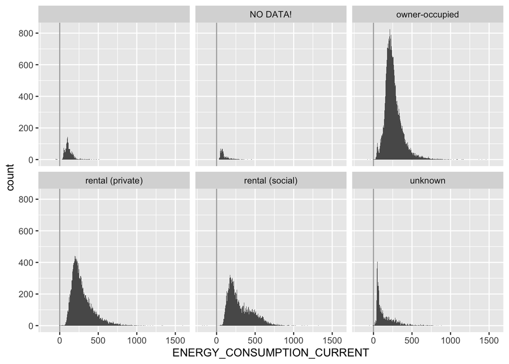

Figure 3.1: Histogram of ENERGY_CONSUMPTION_CURRENT (reference line = 0)

```r
ggplot2::ggplot(sotonUniqueEPCsDT, aes(x = ENERGY_CONSUMPTION_CURRENT)) +
  geom_histogram(binwidth = 5) +
  facet_wrap(~TENURE) +
  geom_vline(xintercept = 0, alpha = 0.4)
```

```r
underZero <- nrow(sotonUniqueEPCsDT[ENERGY_CONSUMPTION_CURRENT < 0])

t <- with(sotonUniqueEPCsDT[ENERGY_CONSUMPTION_CURRENT < 0],
     table(BUILT_FORM,TENURE))


kableExtra::kable(t, caption = "Properties with ENERGY_CONSUMPTION_CURRENT < 0") %>%
  kable_styling()
```

Table 3.1: Properties with ENERGY_CONSUMPTION_CURRENT < 0

|  |  | owner-occupied | rental (social) | unknown |
| --- | --- | --- | --- | --- |
| Detached | 0 | 2 | 0 | 0 |
| End-Terrace | 2 | 0 | 2 | 0 |
| Mid-Terrace | 3 | 1 | 1 | 0 |
| NO DATA! | 0 | 0 | 0 | 2 |
| Semi-Detached | 6 | 0 | 0 | 1 |

```r
# do we think this is caused by solar/wind?
sotonUniqueEPCsDT[, hasWind := ifelse(WIND_TURBINE_COUNT > 0, "Yes", "No")]
#table(sotonUniqueEPCsDT$hasWind)
sotonUniqueEPCsDT[, hasPV := ifelse(PHOTO_SUPPLY >0, "Yes", "No")]
#table(sotonUniqueEPCsDT$hasPV)
sotonUniqueEPCsDT[, consFlag := ifelse(ENERGY_CONSUMPTION_CURRENT < 0, "-ve kWh/y", NA)]
sotonUniqueEPCsDT[, consFlag := ifelse(ENERGY_CONSUMPTION_CURRENT == 0, "0 kWh/y", consFlag)]
sotonUniqueEPCsDT[, consFlag := ifelse(ENERGY_CONSUMPTION_CURRENT > 0 &
                                     ENERGY_CONSUMPTION_CURRENT <= 1, "0-1 kWh/y", consFlag)]
sotonUniqueEPCsDT[, consFlag := ifelse(ENERGY_CONSUMPTION_CURRENT > 1, "1+ kWh/y", consFlag)]

t <- sotonUniqueEPCsDT[, .(nObs = .N), keyby = .(consFlag, hasWind, hasPV)]

kableExtra::kable(t, caption = "Properties in ENERGY_CONSUMPTION_CURRENT category by presence of microgeneration") %>%
  kable_styling()
```

Table 3.1: Properties in ENERGY_CONSUMPTION_CURRENT category by presence of microgeneration

| consFlag | hasWind | hasPV | nObs |
| --- | --- | --- | --- |
| -ve kWh/y | NA | NA | 5 |
| -ve kWh/y | No | NA | 15 |
| 0 kWh/y | NA | NA | 1 |
| 0 kWh/y | No | No | 1 |
| 1+ kWh/y | NA | NA | 5549 |
| 1+ kWh/y | No | NA | 33014 |
| 1+ kWh/y | No | No | 32534 |
| 1+ kWh/y | No | Yes | 447 |
| 1+ kWh/y | Yes | NA | 6 |
| 1+ kWh/y | Yes | No | 28 |

There are only 20 dwellings where ENERGY_CONSUMPTION_CURRENT < 0 and none of them seem to have PV or a wind turbine so we can probably ignore them.

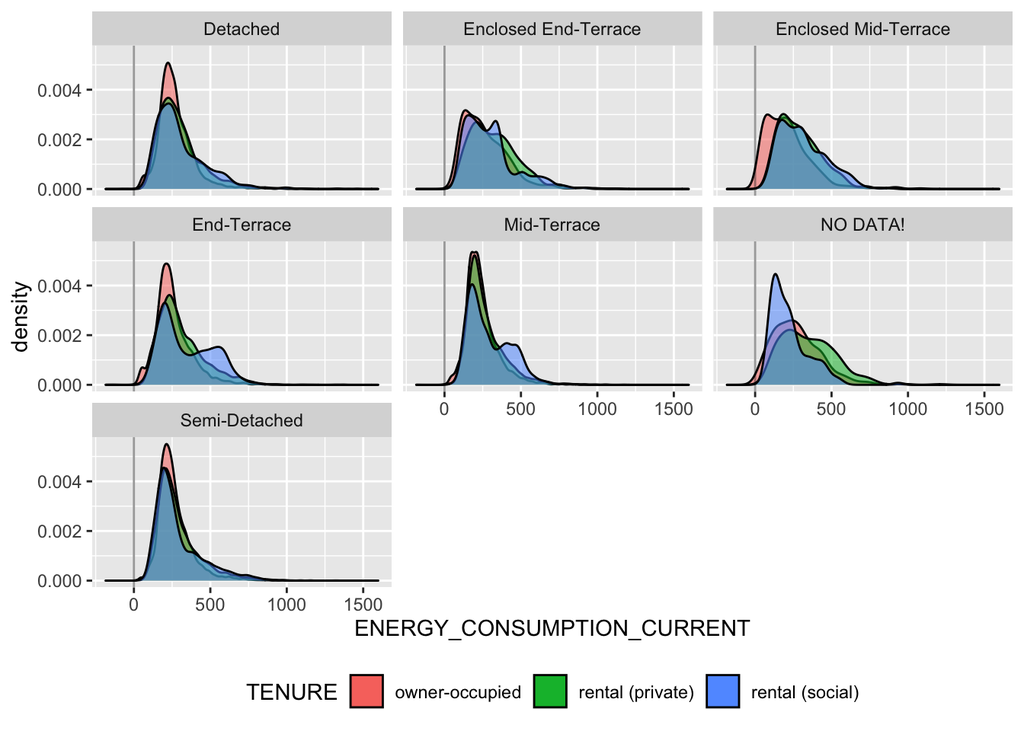

Figure 3.2: Comparing distributions of ENERGY_CONSUMPTION_CURRENT by tenure and built form (reference line = 0)

```r
# repeat with a density plot to allow easy overlap
# exclude those with no data
ggplot2::ggplot(sotonUniqueEPCsDT[TENURE != "NO DATA!" &
                           TENURE != "unknown" &
                           TENURE != ""], aes(x = ENERGY_CONSUMPTION_CURRENT,
                                              fill = TENURE, alpha = 0.2)) +
  geom_density() +
  facet_wrap(~BUILT_FORM) +
  guides(alpha = FALSE) +
  geom_vline(xintercept = 0, alpha = 0.4) +
  theme(legend.position = "bottom")
```

> Recommendation: We should exclude any property where ENERGY_CONSUMPTION_CURRENT <= 0

## 3.2 EPC: Check CO2_EMISSIONS_CURRENT

Next we do the same for current emissions. Repeat the coding for total floor area using 0 and 1 TCO2/y as the threshold of interest.

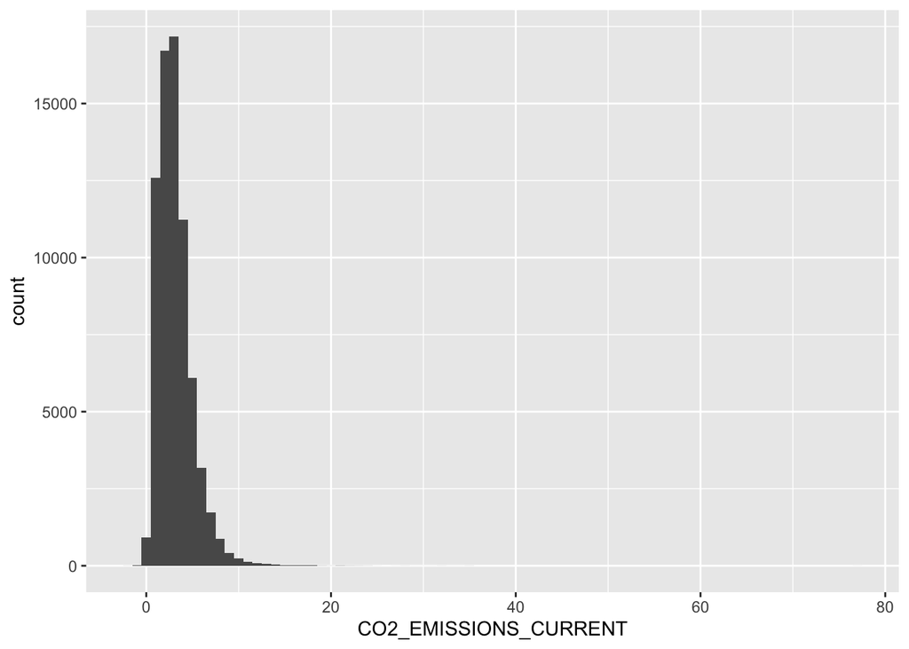

Figure 3.3: Histogram of CO2_EMISSIONS_CURRENT

```r
ggplot2::ggplot(sotonUniqueEPCsDT, aes(x = CO2_EMISSIONS_CURRENT)) +
  geom_histogram(binwidth = 1)
```

```r
nZeroEmissions <- nrow(sotonUniqueEPCsDT[CO2_EMISSIONS_CURRENT < 0])

sotonUniqueEPCsDT[, emissionsFlag := ifelse(CO2_EMISSIONS_CURRENT < 0, "-ve CO2/y", NA)]
sotonUniqueEPCsDT[, emissionsFlag := ifelse(CO2_EMISSIONS_CURRENT == 0, "0 CO2/y", emissionsFlag)]
sotonUniqueEPCsDT[, emissionsFlag := ifelse(CO2_EMISSIONS_CURRENT > 0 &
                                     CO2_EMISSIONS_CURRENT <= 1, "0-1 TCO2/y", emissionsFlag)]
sotonUniqueEPCsDT[, emissionsFlag := ifelse(CO2_EMISSIONS_CURRENT > 1, "1+ TCO2/y", emissionsFlag)]

t <- sotonUniqueEPCsDT[, .(nObs = .N), keyby = .(emissionsFlag, hasWind, hasPV)]

kableExtra::kable(t, caption = "Properties with CO2_EMISSIONS_CURRENT < 0 by presence of microgeneration") %>%
  kable_styling()
```

Table 3.2: Properties with CO2_EMISSIONS_CURRENT < 0 by presence of microgeneration

| emissionsFlag | hasWind | hasPV | nObs |
| --- | --- | --- | --- |
| -ve CO2/y | NA | NA | 4 |
| -ve CO2/y | No | NA | 16 |
| -ve CO2/y | No | No | 2 |
| 0 CO2/y | NA | NA | 5 |
| 0 CO2/y | No | No | 1 |
| 0-1 TCO2/y | NA | NA | 3445 |
| 0-1 TCO2/y | No | NA | 1941 |
| 0-1 TCO2/y | No | No | 532 |
| 0-1 TCO2/y | No | Yes | 19 |
| 0-1 TCO2/y | Yes | NA | 1 |
| 0-1 TCO2/y | Yes | No | 1 |
| 1+ TCO2/y | NA | NA | 2101 |
| 1+ TCO2/y | No | NA | 31072 |
| 1+ TCO2/y | No | No | 32000 |
| 1+ TCO2/y | No | Yes | 428 |
| 1+ TCO2/y | Yes | NA | 5 |
| 1+ TCO2/y | Yes | No | 27 |

```r
kableExtra::kable(round(100*(prop.table(table(sotonUniqueEPCsDT$emissionsFlag,
                                              sotonUniqueEPCsDT$consFlag,
                                              useNA = "always")
                                        )
                             )
                        ,2)
                  , caption = "% properties in CO2_EMISSIONS_CURRENT categories by ENERGY_CONSUMPTION_CURRENT categories") %>%
  kable_styling()
```

Table 3.2: % properties in CO2_EMISSIONS_CURRENT categories by ENERGY_CONSUMPTION_CURRENT categories

|  | -ve kWh/y | 0 kWh/y | 1+ kWh/y | NA |
| --- | --- | --- | --- | --- |
| -ve CO2/y | 0.03 | 0 | 0.00 | 0 |
| 0 CO2/y | 0.00 | 0 | 0.00 | 0 |
| 0-1 TCO2/y | 0.00 | 0 | 8.29 | 0 |
| 1+ TCO2/y | 0.00 | 0 | 91.67 | 0 |
| NA | 0.00 | 0 | 0.00 | 0 |

> Recommendation: we should exclude any property where CO2_EMISSIONS_CURRENT <= 0

## 3.3 EPC: Check ENVIRONMENT_IMPACT_CURRENT

`Environmental impact` is some sort of numerical scale that unlikely to be normally distributed.

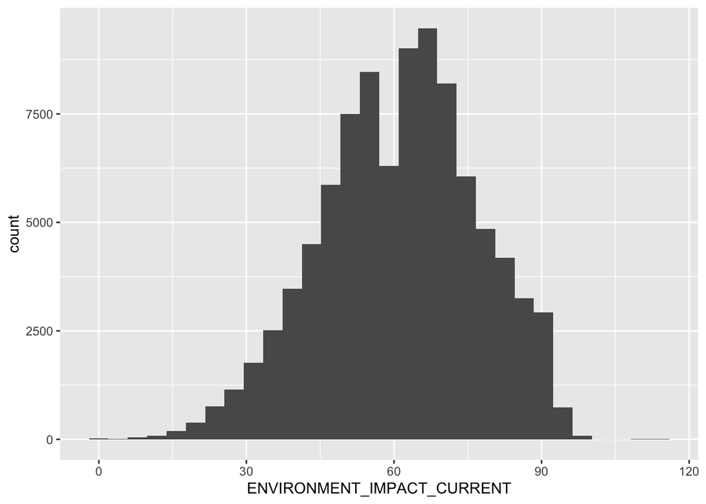

Figure 3.4: Histogram of ENVIRONMENT_IMPACT_CURRENT

```r
ggplot2::ggplot(sotonEPCsDT, aes(x = ENVIRONMENT_IMPACT_CURRENT)) +
  geom_histogram()
```

`Environmental impact` should decrease as emissions increase…

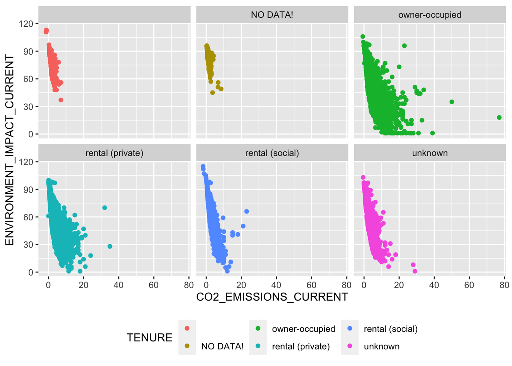

Figure 3.5: Plot of ENVIRONMENT_IMPACT_CURRENT vs CO2_EMISSIONS_CURRENT

```r
ggplot2::ggplot(sotonEPCsDT, aes(x = CO2_EMISSIONS_CURRENT,
                           y = ENVIRONMENT_IMPACT_CURRENT,
                           colour = TENURE)) +
  geom_point() +
  facet_wrap(TENURE~.) +
  theme(legend.position = "bottom")
```

It does but what is the relationship between ENVIRONMENT_IMPACT_CURRENT and CO2_EMISSIONS_CURRENT? It is not linear… (Figure 3.5) and there are some interesting outliers.

## 3.4 EPC: Check TOTAL_FLOOR_AREA

Repeat the coding for total floor area using 5 m2 as the threshold of interest.

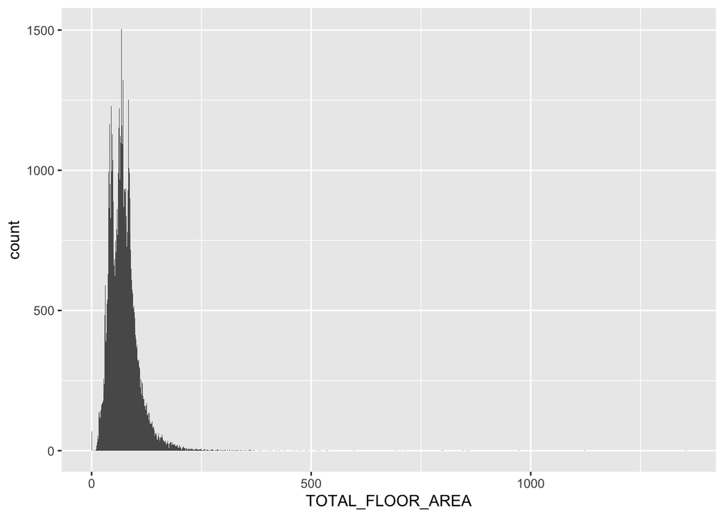

Figure 3.6: Histogram of TOTAL_FLOOR_AREA

```r
ggplot2::ggplot(sotonUniqueEPCsDT, aes(x = TOTAL_FLOOR_AREA)) +
  geom_histogram(binwidth = 1)
```

```r
nZeroFloorArea <- nrow(sotonUniqueEPCsDT[TOTAL_FLOOR_AREA < 0])

sotonUniqueEPCsDT[, floorFlag := ifelse(TOTAL_FLOOR_AREA == 0, "0 m2", NA)]
sotonUniqueEPCsDT[, floorFlag := ifelse(TOTAL_FLOOR_AREA > 0 &
                                     TOTAL_FLOOR_AREA <= 5, "0-5 m2", floorFlag)]
sotonUniqueEPCsDT[, floorFlag := ifelse(TOTAL_FLOOR_AREA > 5, "5+ m2", floorFlag)]

t <- with(sotonUniqueEPCsDT, table(floorFlag, consFlag))

kableExtra::kable(round(100*prop.table(t),3), caption = "% properties with TOTAL_FLOOR_AREA category by ENERGY_CONSUMPTION_CURRENT category") %>%
  kable_styling()
```

Table 3.3: % properties with TOTAL_FLOOR_AREA category by ENERGY_CONSUMPTION_CURRENT category

|  | -ve kWh/y | 0 kWh/y | 1+ kWh/y |
| --- | --- | --- | --- |
| 0 m2 | 0.000 | 0.000 | 0.096 |
| 0-5 m2 | 0.000 | 0.000 | 0.001 |
| 5+ m2 | 0.028 | 0.003 | 99.872 |

```r
kableExtra::kable(head(sotonUniqueEPCsDT[, .(BUILDING_REFERENCE_NUMBER, PROPERTY_TYPE, TOTAL_FLOOR_AREA,
                                    ENERGY_CONSUMPTION_CURRENT)][order(-TOTAL_FLOOR_AREA)], 10),
                  caption = "Top 10 by floor area (largest)") %>%
  kable_styling()
```

Table 3.3: Top 10 by floor area (largest)

| BUILDING_REFERENCE_NUMBER | PROPERTY_TYPE | TOTAL_FLOOR_AREA | ENERGY_CONSUMPTION_CURRENT |
| --- | --- | --- | --- |
| 9507976768 | House | 1353.680 | 140 |
| 3834614378 | House | 1123.000 | 120 |
| 9808638568 | House | 973.210 | 522 |
| 5181048568 | House | 861.360 | 279 |
| 1654050778 | House | 855.000 | 170 |
| 898835568 | House | 846.421 | 161 |
| 8250419178 | House | 800.000 | 185 |
| 3914088378 | House | 796.000 | 216 |
| 2590863278 | House | 714.000 | 224 |
| 4947642078 | Flat | 694.000 | 88 |

```r
kableExtra::kable(head(sotonUniqueEPCsDT[, .(BUILDING_REFERENCE_NUMBER, PROPERTY_TYPE, TOTAL_FLOOR_AREA,
                                    ENERGY_CONSUMPTION_CURRENT)][order(TOTAL_FLOOR_AREA)], 10),
                  caption = "Bottom 10 by floor area (smallest)") %>%
  kable_styling()
```

Table 3.3: Bottom 10 by floor area (smallest)

| BUILDING_REFERENCE_NUMBER | PROPERTY_TYPE | TOTAL_FLOOR_AREA | ENERGY_CONSUMPTION_CURRENT |
| --- | --- | --- | --- |
| 184420668 | Flat | 0 | 104 |
| 627876968 | Flat | 0 | 58 |
| 666790668 | Flat | 0 | 110 |
| 747876968 | Flat | 0 | 70 |
| 884420668 | Flat | 0 | 119 |
| 884838868 | Flat | 0 | 71 |
| 1478001668 | Flat | 0 | 115 |
| 1926004568 | Flat | 0 | 144 |
| 1935420668 | Flat | 0 | 103 |
| 2145420668 | Flat | 0 | 117 |

```r
kableExtra::kable(round(100*prop.table(t),3), caption = "% properties with TOTAL_FLOOR_AREA category by ENERGY_CONSUMPTION_CURRENT category") %>%
  kable_styling()
```

Table 3.3: % properties with TOTAL_FLOOR_AREA category by ENERGY_CONSUMPTION_CURRENT category

|  | -ve kWh/y | 0 kWh/y | 1+ kWh/y |
| --- | --- | --- | --- |
| 0 m2 | 0.000 | 0.000 | 0.096 |
| 0-5 m2 | 0.000 | 0.000 | 0.001 |
| 5+ m2 | 0.028 | 0.003 | 99.872 |

Table 3.3 shows that the properties with floor area of < 5m2 are not necessarily the ones with 0 or negative kWh values. Nevertheless they represent a small proportion of all properties.

The scale of the x axis in Figure 3.6 also suggests a few very large properties.

> Recommendation: We should exclude any property where TOTAL_FLOOR_AREA <= 5

## 3.5 EPC: Check ‘missing’ EPC rates

We know that we do not have EPC records for every dwelling. But how many are we missing? We will check this at MSOA level as it allows us to link to other MSOA level datasets that tell us how many households, dwellings or energy meters to expect. Arguably it would be better to do this at LSOA level but…

First we’ll use the BEIS 2018 MSOA level annual electricity data to estimate the number of meters (not properties) - some addresses can have 2 meters (e.g. standard & economy 7). However this is more useful than the number of gas meters since not all dwellings have mains gas but all (should?) have an electricity meter.

```r
message("Number of electricity & gas meters")
```

```
## Number of electricity & gas meters
```

```r
sotonEnergyDT[, .(nElecMeters = sum(nElecMeters),
                  nGasMeters = sum(nGasMeters)), keyby = .(LAName)]
```

```
##         LAName nElecMeters nGasMeters
## 1: Southampton      108333      81645
```

Next we’ll check for the number of households reported by the 2011 Census.

> would be better to use the Census dwellings counts but this gives us tenure which is useful

```r
#censusDT <- data.table::fread(path.expand("~/data/"))

t <- sotonCensus2011_DT[, .(nHouseholds = sum(nHHs_deprivation)), keyby = .(LAName)]
kableExtra::kable(t, caption = "Census derived household counts") %>%
  kable_styling()
```

Table 3.4: Census derived household counts

| LAName | nHouseholds |
| --- | --- |
| Southampton | 98254 |

That’s lower than the number of electricity meters (as expected) but note that as it is a count of households rather than dwellings, it doesn’t allow for dwellings that were empty on census night.

```r
# Postcodes don't help - no count of addresses in the data (there used to be??)
# but we can use it to check which Soton postcodes are missing from the EPC file

sotonPostcodesReducedDT[, c("pc_chunk1","pc_chunk2" ) := tstrsplit(pcds,
                                                                   split = " "
                                                                   )
                        ]
```

We should not have single digit postcodes in the postcode data - i.e. S01 should not be there (since 1993). Southampton City is unusual in only having [double digit postcodes](https://en.wikipedia.org/wiki/SO_postcode_area).

```r
# EPC
# set up counters
# use final cleaned EPC data
sotonUniqueEPCsDT[, epcIsSocialRent := ifelse(TENURE == "rental (social)", 1, 0)]
sotonUniqueEPCsDT[, epcIsPrivateRent := ifelse(TENURE == "rental (private)", 1, 0)]
sotonUniqueEPCsDT[, epcIsOwnerOcc := ifelse(TENURE == "owner-occupied", 1, 0)]
sotonUniqueEPCsDT[, epcIsUnknownTenure := ifelse(TENURE == "NO DATA!" |
                                          TENURE == "" , 1, 0)]
# aggregate EPCs to postcodes
sotonEpcPostcodes_DT <- sotonUniqueEPCsDT[, .(nEPCs = .N,
                                              sumEPC_tCO2 = sum(CO2_EMISSIONS_CURRENT, na.rm = TRUE),
                                     n_epcIsSocialRent = sum(epcIsSocialRent, na.rm = TRUE),
                                     n_epcIsPrivateRent = sum(epcIsPrivateRent, na.rm = TRUE),
                                     n_epcIsOwnerOcc = sum(epcIsOwnerOcc, na.rm = TRUE),
                                     n_epcIsUnknownTenure = sum(epcIsUnknownTenure, na.rm = TRUE),
                               sumEpcMWh = sum(ENERGY_CONSUMPTION_CURRENT* TOTAL_FLOOR_AREA)/1000), # crucial as ENERGY_CONSUMPTION_CURRENT = kWh/m2
                           keyby = .(POSTCODE, LOCAL_AUTHORITY_LABEL)]

sotonEpcPostcodes_DT[, c("pc_chunk1","pc_chunk2" ) := tstrsplit(POSTCODE,
                                                                   split = " "
                                                                   )
                        ]
# check original EPC data for Soton - which postcodes are covered?
sotonEPCsDT[, c("pc_chunk1","pc_chunk2" ) := tstrsplit(POSTCODE,
                                                                   split = " "
                                                                   )
                        ]
t <- sotonEPCsDT[, .(nEPCs = .N), keyby = .(postcode_sector = pc_chunk1)]

kableExtra::kable(t, caption = "Count of most recent EPCs per postcode sector for Southampton") %>%
  kable_styling()
```

| postcode_sector | nEPCs |
| --- | --- |
| SO14 | 14213 |
| SO15 | 17855 |
| SO16 | 20270 |
| SO17 | 8446 |
| SO18 | 10661 |
| SO19 | 20388 |

It looks like we have EPCs for each postcode sector and we only have double digit postcodes which is good.

```r
# match the EPC postcode summaries to the postcode extract
sotonPostcodesReducedDT[, POSTCODE_s := stringr::str_remove(pcds, " ")]
setkey(sotonPostcodesReducedDT, POSTCODE_s)
sotonPostcodesReducedDT[, MSOACode := msoa11]
message("Number of postcodes: ",uniqueN(sotonPostcodesReducedDT$POSTCODE_s))
```

```
## Number of postcodes: 14228
```

```r
sotonEpcPostcodes_DT[, POSTCODE_s := stringr::str_remove(POSTCODE, " ")]
setkey(sotonEpcPostcodes_DT, POSTCODE_s)
message("Number of postcodes with EPCs: ",uniqueN(sotonEpcPostcodes_DT$POSTCODE_s))
```

```
## Number of postcodes with EPCs: 5107
```

```r
dt <- sotonEpcPostcodes_DT[sotonPostcodesReducedDT]

# aggregate to MSOA - watch for NAs where no EPCs in a given postcode
sotonEpcMSOA_DT <- dt[, .(nEPCs = sum(nEPCs, na.rm = TRUE),
                          sumEPC_tCO2 = sum(sumEPC_tCO2, na.rm = TRUE),
                                        n_epcIsSocialRent = sum(n_epcIsSocialRent, na.rm = TRUE),
                                        n_epcIsPrivateRent = sum(n_epcIsPrivateRent, na.rm = TRUE),
                                        n_epcIsOwnerOcc = sum(n_epcIsOwnerOcc, na.rm = TRUE),
                                        n_epcIsUnknownTenure = sum(n_epcIsUnknownTenure, na.rm = TRUE),
                                        sumEpcMWh = sum(sumEpcMWh, na.rm = TRUE)
                                        ),
                                    keyby = .(MSOACode) # change name on the fly for easier matching
                                    ]

#summary(sotonEpcMSOA_DT)
```

So we have some postcodes with no EPCs.

Join the estimates together at MSOA level for comparison. There are 32 MSOAs in Southampton.

```r
# 32 LSOAs in Soton
# add census & deprivation to energy
setkey(sotonEnergyDT, MSOACode)
setkey(sotonCensus2011_DT, MSOACode)
setkey(sotonEpcMSOA_DT, MSOACode)

sotonMSOA_DT <- sotonCensus2011_DT[sotonEnergyDT]
#names(sotonMSOA_DT)
sotonMSOA_DT <- sotonEpcMSOA_DT[sotonMSOA_DT]
#names(sotonMSOA_DT)

# add MSOA names from the postcode LUT

msoaNamesDT <- data.table::as.data.table(readxl::read_xlsx(path.expand("~/data/UK_postcodes/NSPL_AUG_2020_UK/Documents/MSOA (2011) names and codes UK as at 12_12.xlsx")))
msoaNamesDT[, MSOACode := MSOA11CD]
msoaNamesDT[, MSOAName := MSOA11NM]

setkey(msoaNamesDT, MSOACode)
sotonMSOA_DT <- msoaNamesDT[sotonMSOA_DT]

#names(sotonMSOA_DT)
```

Table3.6 compares all three sources of counts. Clearly we have fewer EPCs in 2020 than both households in 2011 and electricity meters in 2018.

```r
t <- sotonMSOA_DT[, .(nHouseholds_2011 = sum(nHHs_tenure),
                      nElecMeters_2018 = sum(nElecMeters),
                      nEPCs_2020 = sum(nEPCs),
                      total_MWh_BEIS_2018 = sum(beisEnergyMWh),
                      total_kWh_EPCs_2020 = sum(sumEpcMWh)), keyby = .(LAName)]

kableExtra::kable(t, caption = "Comparison of different estimates of the number of dwellings and total energy use") %>%
  kable_styling()
```

Table 3.6: Comparison of different estimates of the number of dwellings and total energy use

| LAName | nHouseholds_2011 | nElecMeters_2018 | nEPCs_2020 | total_MWh_BEIS_2018 | total_kWh_EPCs_2020 |
| --- | --- | --- | --- | --- | --- |
| Southampton | 98254 | 108333 | 71527 | 1276983 | 1290907 |

```r
nHouseholds_2011f <- sum(sotonMSOA_DT$nHHs_tenure)
nElecMeters_2018f <- sum(sotonMSOA_DT$nElecMeters)
nEPCs_2020f <- sum(sotonMSOA_DT$nEPCs)

makePC <- function(x,y,r){
  # make a percent of x/y and round it to r decimal places
  pc <- round(100*(x/y),r)
  return(pc)
}
```

The number of EPCs we have is:

- 72.8% of Census 2011 households
- 66% of the recorded 2018 electricity meters

We can also see that despite having ‘missing’ EPCs, the estimated total EPC-derived energy demand is marginally higher than the BEIS-derived weather corrected energy demand data. Given that the BEIS data accounts for all heating, cooking, hot water, lighting and appliance use we would expect the EPC data to be lower *even if no EPCs were missing…*

### 3.5.1 Missing rates by MSOA

Figure 3.7 suggests that rates vary considerably by MSOA but are relatively consistent across the two baseline ‘truth’ estimates with the exception of E02003577 which appears to have many more EPCs than Census 2011 households. It is worth noting that [this MSOA](https://www.localhealth.org.uk/#c=report&chapter=c01&report=r01&selgeo1=msoa_2011.E02003577&selgeo2=eng.E92000001) covers the city centre and dock areas which have had substantial new build since 2011 and so may have households inhabiting dwellings that did not exist at Census 2011. This is also supported by the considerably higher EPC derived energy demand data compared to BEIS’s 2018 data - although it suggests the dwellings are either very new (since 2018) or are yet to be occupied.

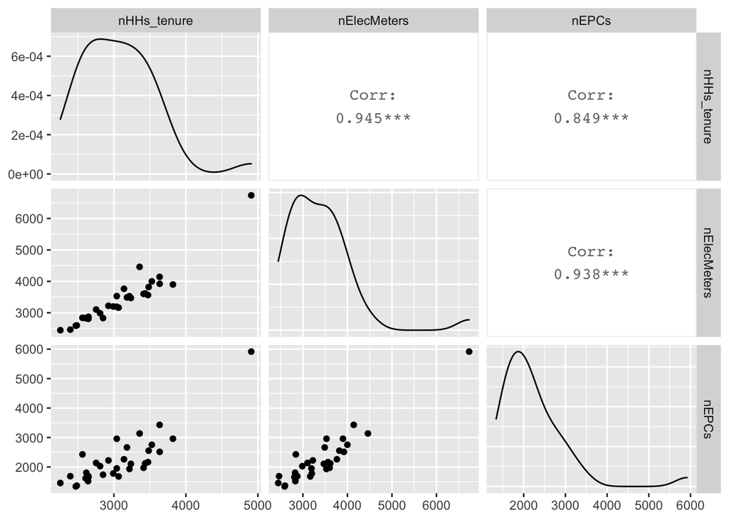

Figure 3.7: Pairs plot of estimates of meters, households and EPCs by MSOA

```r
ggpairs(sotonMSOA_DT[, .(nHHs_tenure, nElecMeters, nEPCs)])
```

Figure 3.8 (see Table 7.1 below for details) extends this analysis to show the % missing compared to the relevant baseline coloured by the % of owner-occupied dwellings in the MSOA according to Census 2011. As we would expect given the EPC inspection process, those MSOAs with the lowest EPC coverage on both baseline measures tend to have higher proportions of owner occupiers and therefore are likely to have more dwellings that have never required an EPC inspection.

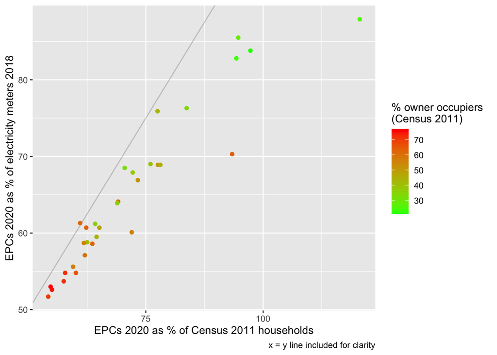

Figure 3.8: % ‘missing’ rates comparison

```r
t <- sotonMSOA_DT[, .(MSOAName, MSOACode, nHHs_tenure,nElecMeters,nEPCs,
                      dep0_pc, socRent_pc, privRent_pc, ownerOcc_pc,sumEpcMWh, beisEnergyMWh )]

t[, pc_missingHH := makePC(nEPCs,nHHs_tenure,1)]
t[, pc_missingMeters := makePC(nEPCs,nElecMeters,1)]
t[, pc_energyBEIS := makePC(sumEpcMWh,beisEnergyMWh,1)]

kt1 <- t

ggplot2::ggplot(t, aes(x = pc_missingHH,
                       y = pc_missingMeters,
                       colour = round(ownerOcc_pc))) +
  geom_abline(alpha = 0.2, slope=1, intercept=0) +
  geom_point() +
  scale_color_continuous(name = "% owner occupiers \n(Census 2011)", high = "red", low = "green") +
  #theme(legend.position = "bottom") +
  labs(x = "EPCs 2020 as % of Census 2011 households",
       y = "EPCs 2020 as % of electricity meters 2018",
       caption = "x = y line included for clarity")
```

```r
outlierMSOA <- t[pc_missingHH > 100]
```

We can use the same approach to compare estimates of total energy demand at the MSOA level. To do this we compare:

- estimated total energy demand in MWh/year derived from the EPC estimates. This energy only relates to `current primary energy` (space heating, hot water and lighting) and of course also suffers from missing EPCs (see above)
- observed electricity and gas demand collated by BEIS for their sub-national statistical series. This applies to all domestic energy demand but the most recent data is for 2018 so will suffer from the absence of dwellings that are present in the most recent EPC data (see above).

We should not expect the values to match but we might reasonably expect a correlation.

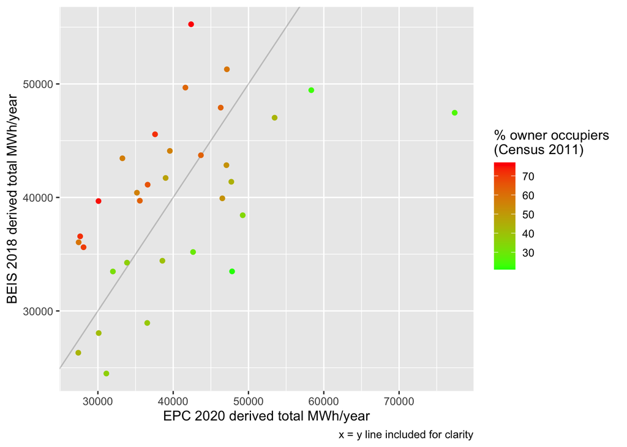

Figure 3.9: Energy demand comparison

```r
ggplot2::ggplot(t, aes(x = sumEpcMWh,
                       y = beisEnergyMWh,
                       colour = round(ownerOcc_pc))) +
  geom_abline(alpha = 0.2, slope=1, intercept=0) +
  geom_point() +
  scale_color_continuous(name = "% owner occupiers \n(Census 2011)", high = "red", low = "green") +
  #theme(legend.position = "bottom") +
  labs(x = "EPC 2020 derived total MWh/year",
       y = "BEIS 2018 derived total MWh/year",
       caption = "x = y line included for clarity")
```

```r
outlier <- t[sumEpcMWh > 70000]
```

Figure 3.9 shows that both of these are true. MSOAs with a high proportion of owner occupiers (and therefore more likely to have missing EPCs) tend to have higher observed energy demand than the EOC data suggests - they are above the reference line. MSOAs with a lower proportion of owner occupiers (and therefore more likely to have more complete EPC coverage) tend to be on or below the line. As before we have the same notable outlier (E02003577) and for the same reasons… In this case this produces a much higher energy demand estimate than the BEIS 2018 data records.

## 3.6 BEIS: Check data

While we’re here we’ll also check the BEIS data. Table 3.7 shows the five highest and lowest MSOAs by annual electricity use.

```r
t1 <- head(sotonMSOA_DT[, .(MSOA11NM, MSOA11CD, beisElecMWh, nElecMeters,
                            beisGasMWh, nGasMeters)][order(-beisElecMWh)],5)

kableExtra::kable(t1, caption = "Southampton MSOAs: BEIS 2018 energy data ordered by highest electricity (top 5)") %>%
  kable_styling()
```

Table 3.7: Southampton MSOAs: BEIS 2018 energy data ordered by highest electricity (top 5)

| MSOA11NM | MSOA11CD | beisElecMWh | nElecMeters | beisGasMWh | nGasMeters |
| --- | --- | --- | --- | --- | --- |
| Southampton 029 | E02003577 | 27352.70 | 6734 | 20108.63 | 2420 |
| Southampton 014 | E02003562 | 14757.18 | 3921 | 36532.48 | 2983 |
| Southampton 022 | E02003570 | 14719.37 | 4142 | 34730.60 | 3083 |
| Southampton 031 | E02003579 | 13860.94 | 4460 | 34052.12 | 3068 |
| Southampton 021 | E02003569 | 13719.22 | 3999 | 27661.45 | 2722 |

```r
t2 <- tail(sotonMSOA_DT[, .(MSOA11NM, MSOA11CD, beisElecMWh, nElecMeters,
                            beisGasMWh, nGasMeters)][order(-beisElecMWh)],5)

kableExtra::kable(t2, caption = "Southampton MSOAs: BEIS 2018 energy data ordered by lowest electricity (bottom 5)") %>%
  kable_styling()
```

Table 3.7: Southampton MSOAs: BEIS 2018 energy data ordered by lowest electricity (bottom 5)

| MSOA11NM | MSOA11CD | beisElecMWh | nElecMeters | beisGasMWh | nGasMeters |
| --- | --- | --- | --- | --- | --- |
| Southampton 024 | E02003572 | 9347.893 | 2597 | 30332.49 | 2381 |
| Southampton 018 | E02003566 | 9221.544 | 2831 | 26826.22 | 2607 |
| Southampton 008 | E02003556 | 9199.673 | 2589 | 26412.36 | 2295 |
| Southampton 003 | E02003551 | 8957.742 | 2446 | 17358.87 | 1649 |
| Southampton 005 | E02003553 | 8479.993 | 2464 | 24996.91 | 2303 |

# 4 Summarise and save EPC data for re-use

We have identified some issues with a small number of the properties in the EPC dataset. These are not unexpected given that much of the estimates rely on partial or presumed data. Data entry errors are also quite likely. As a result we exclude:

- any property where ENERGY_CONSUMPTION_CURRENT <= 0
- any property where TOTAL_FLOOR_AREA <= 5
- any property where CO2_EMISSIONS_CURRENT <= 0

```r
finalEPCDT <- sotonUniqueEPCsDT[ENERGY_CONSUMPTION_CURRENT > 0 &
                      TOTAL_FLOOR_AREA > 5 &
                      CO2_EMISSIONS_CURRENT > 0]

skimr::skim(finalEPCDT)
```

Table 4.1: Data summary

| Name | finalEPCDT |
| --- | --- |
| Number of rows | 71502 |
| Number of columns | 24 |
| _______________________ |  |
| Column type frequency: |  |
| character | 12 |
| Date | 2 |
| numeric | 10 |
| ________________________ |  |
| Group variables | None |

**Variable type: character**

| skim_variable | n_missing | complete_rate | min | max | empty | n_unique | whitespace |
| --- | --- | --- | --- | --- | --- | --- | --- |
| BUILDING_REFERENCE_NUMBER | 0 | 1.00 | 17 | 21 | 0 | 71502 | 0 |
| LMK_KEY | 0 | 1.00 | 29 | 34 | 0 | 71502 | 0 |
| PROPERTY_TYPE | 0 | 1.00 | 4 | 10 | 0 | 5 | 0 |
| BUILT_FORM | 0 | 1.00 | 8 | 20 | 0 | 7 | 0 |
| TENURE | 0 | 1.00 | 0 | 16 | 1905 | 6 | 0 |
| POSTCODE | 0 | 1.00 | 8 | 8 | 0 | 5105 | 0 |
| LOCAL_AUTHORITY_LABEL | 0 | 1.00 | 11 | 11 | 0 | 1 | 0 |
| hasWind | 5546 | 0.92 | 2 | 3 | 0 | 2 | 0 |
| hasPV | 38495 | 0.46 | 2 | 3 | 0 | 2 | 0 |
| consFlag | 0 | 1.00 | 8 | 8 | 0 | 1 | 0 |
| emissionsFlag | 0 | 1.00 | 9 | 10 | 0 | 2 | 0 |
| floorFlag | 0 | 1.00 | 5 | 5 | 0 | 1 | 0 |

**Variable type: Date**

| skim_variable | n_missing | complete_rate | min | max | median | n_unique |
| --- | --- | --- | --- | --- | --- | --- |
| LODGEMENT_DATE | 0 | 1 | 2008-10-01 | 2020-06-30 | 2014-10-22 | 4132 |
| INSPECTION_DATE | 0 | 1 | 2007-03-02 | 2020-06-30 | 2014-10-14 | 3906 |

**Variable type: numeric**

| skim_variable | n_missing | complete_rate | mean | sd | p0 | p25 | p50 | p75 | p100 | hist |
| --- | --- | --- | --- | --- | --- | --- | --- | --- | --- | --- |
| ENVIRONMENT_IMPACT_CURRENT | 0 | 1.00 | 62.51 | 15.72 | 1.00 | 52.0 | 63.00 | 73 | 100.00 | ▁▂▆▇▂ |
| ENERGY_CONSUMPTION_CURRENT | 0 | 1.00 | 263.23 | 140.47 | 4.00 | 174.0 | 233.00 | 327 | 1597.00 | ▇▂▁▁▁ |
| CO2_EMISSIONS_CURRENT | 0 | 1.00 | 3.17 | 1.94 | 0.10 | 1.8 | 2.85 | 4 | 77.00 | ▇▁▁▁▁ |
| PHOTO_SUPPLY | 38495 | 0.46 | 0.59 | 5.11 | 0.00 | 0.0 | 0.00 | 0 | 100.00 | ▇▁▁▁▁ |
| WIND_TURBINE_COUNT | 5546 | 0.92 | 0.00 | 0.02 | -1.00 | 0.0 | 0.00 | 0 | 1.00 | ▁▁▇▁▁ |
| TOTAL_FLOOR_AREA | 0 | 1.00 | 73.05 | 34.86 | 5.85 | 49.0 | 69.00 | 87 | 1353.68 | ▇▁▁▁▁ |
| epcIsSocialRent | 0 | 1.00 | 0.21 | 0.40 | 0.00 | 0.0 | 0.00 | 0 | 1.00 | ▇▁▁▁▂ |
| epcIsPrivateRent | 0 | 1.00 | 0.27 | 0.44 | 0.00 | 0.0 | 0.00 | 1 | 1.00 | ▇▁▁▁▃ |
| epcIsOwnerOcc | 0 | 1.00 | 0.41 | 0.49 | 0.00 | 0.0 | 0.00 | 1 | 1.00 | ▇▁▁▁▆ |
| epcIsUnknownTenure | 0 | 1.00 | 0.04 | 0.19 | 0.00 | 0.0 | 0.00 | 0 | 1.00 | ▇▁▁▁▁ |

This leaves us with a total of 71,502 properties.

```r
finalEPCDT[, POSTCODE_s := stringr::str_remove_all(POSTCODE, " ")]
sotonPostcodesReducedDT[, POSTCODE_s := stringr::str_remove_all(pcds, " ")]
setkey(finalEPCDT, POSTCODE_s)
setkey(sotonPostcodesReducedDT, POSTCODE_s)
dt <- sotonPostcodesReducedDT[finalEPCDT]
dt[, MSOACode := msoa11]

setkey(dt, MSOACode)
setkey(sotonCensus2011_DT, MSOACode)

dt <- sotonCensus2011_DT[dt]

of <- path.expand("~/data/EW_epc/domestic-E06000045-Southampton/EPCs_liveFinalClean.csv")
data.table::fwrite(dt, file = of)

message("Gziping ", of)
```

```
## Gziping /Users/ben/data/EW_epc/domestic-E06000045-Southampton/EPCs_liveFinalClean.csv
```

```r
# Gzip it
# in case it fails (it will on windows - you will be left with a .csv file)
try(system( paste0("gzip -f '", of,"'"))) # include ' or it breaks on spaces
message("Gzipped ", of)
```

```
## Gzipped /Users/ben/data/EW_epc/domestic-E06000045-Southampton/EPCs_liveFinalClean.csv
```

NB: this failed to match an EPC postcode to an MSOA for 72 EPCs The table below shows which postcodes these were by date.

```r
dt[is.na(MSOACode), .(nEPCs = .N), keyby = .(POSTCODE_s, TENURE, INSPECTION_DATE)]
```

```
##     POSTCODE_s           TENURE INSPECTION_DATE nEPCs
##  1:    SO156GB          unknown      2015-04-08     3
##  2:    SO156GB          unknown      2015-06-09     1
##  3:    SO156GB          unknown      2015-07-06    24
##  4:    SO156GB          unknown      2015-08-04    12
##  5:    SO156GB          unknown      2015-08-14     9
##  6:    SO156GB          unknown      2015-08-19     1
##  7:    SO160AL                       2009-02-17     4
##  8:    SO160AL rental (private)      2019-11-20     2
##  9:    SO162AJ          unknown      2018-03-22     2
## 10:    SO167HE   owner-occupied      2009-11-30     1
## 11:    SO167HE   owner-occupied      2017-10-04     1
## 12:    SO168AD                       2011-03-18     1
## 13:    SO168AD   owner-occupied      2008-10-01     1
## 14:    SO168AD   owner-occupied      2009-09-29     1
## 15:    SO168AD   owner-occupied      2019-04-08     1
## 16:    SO168AD   owner-occupied      2020-06-17     1
## 17:    SO181HS rental (private)      2010-04-27     1
## 18:    SO185BR   owner-occupied      2018-06-05     1
## 19:    SO185BS   owner-occupied      2012-02-15     1
## 20:    SO185BS   owner-occupied      2018-03-14     1
## 21:    SO196AQ          unknown      2014-11-05     3
##     POSTCODE_s           TENURE INSPECTION_DATE nEPCs
```

# 5 Summarise and save MSOA aggregates for re-use

Finally we save the MSOA table into the repo data directory for future use. We don’t usually advocate keeping data in a git repo but this is small, aggregated and [mostly harmless](https://en.wikipedia.org/wiki/Mostly_Harmless).

```r
of <-  here::here("data", "sotonMSOAdata.csv")

data.table::fwrite(sotonMSOA_DT, of)
message("Saved ", nrow(sotonMSOA_DT), " rows of data.")
```

```
## Saved 32 rows of data.
```

# 6 R packages used

- rmarkdown (Allaire et al. 2018)
- bookdown (Xie 2016a)
- knitr (Xie 2016b)
- data.table (Dowle et al. 2015)
- ggplot2 (Wickham 2009)
- kableExtra (Zhu 2018)
- readxl (Wickham and Bryan 2017)

# 7 Annex

## 7.1 Tables

```r
kableExtra::kable(kt1[order(-pc_missingHH)], digits = 2, caption = "EPC records as a % of n census households and n meters per MSOA") %>%
  kable_styling()
```

Table 7.1: EPC records as a % of n census households and n meters per MSOA

| MSOAName | MSOACode | nHHs_tenure | nElecMeters | nEPCs | dep0_pc | socRent_pc | privRent_pc | ownerOcc_pc | sumEpcMWh | beisEnergyMWh | pc_missingHH | pc_missingMeters | pc_energyBEIS |
| --- | --- | --- | --- | --- | --- | --- | --- | --- | --- | --- | --- | --- | --- |
| Southampton 029 | E02003577 | 4908 | 6734 | 5917 | 37.92 | 27.61 | 43.09 | 24.67 | 77383.23 | 47461.33 | 120.6 | 87.9 | 163.0 |
| Southampton 023 | E02003571 | 3040 | 3530 | 2958 | 47.96 | 20.23 | 56.97 | 21.48 | 47820.53 | 33485.69 | 97.3 | 83.8 | 142.8 |
| Southampton 017 | E02003565 | 2563 | 2840 | 2427 | 48.81 | 11.63 | 57.24 | 28.95 | 42637.78 | 35191.63 | 94.7 | 85.5 | 121.2 |
| Southampton 022 | E02003570 | 3635 | 4142 | 3429 | 25.56 | 29.82 | 45.69 | 22.59 | 58338.87 | 49449.97 | 94.3 | 82.8 | 118.0 |
| Southampton 031 | E02003579 | 3357 | 4460 | 3137 | 44.92 | 11.56 | 23.80 | 63.09 | 46309.49 | 47913.06 | 93.4 | 70.3 | 96.7 |
| Southampton 013 | E02003561 | 3181 | 3489 | 2663 | 39.80 | 19.68 | 44.73 | 33.98 | 49231.81 | 38430.85 | 83.7 | 76.3 | 128.1 |
| Southampton 021 | E02003569 | 3527 | 3999 | 2754 | 40.71 | 15.00 | 38.28 | 44.32 | 47718.63 | 41380.67 | 78.1 | 68.9 | 115.3 |
| Southampton 009 | E02003557 | 2753 | 3103 | 2137 | 50.78 | 7.37 | 38.98 | 52.49 | 47067.97 | 42842.23 | 77.6 | 68.9 | 109.9 |
| Southampton 020 | E02003568 | 3820 | 3900 | 2959 | 50.08 | 4.53 | 50.92 | 42.93 | 53468.76 | 47024.09 | 77.5 | 75.9 | 113.7 |
| Southampton 010 | E02003558 | 2924 | 3222 | 2223 | 33.96 | 32.32 | 25.82 | 39.81 | 38565.55 | 34421.99 | 76.0 | 69.0 | 112.0 |
| Southampton 015 | E02003563 | 3483 | 3818 | 2553 | 37.81 | 21.79 | 24.17 | 51.79 | 46524.57 | 39920.85 | 73.3 | 66.9 | 116.5 |
| Southampton 027 | E02003575 | 2808 | 2987 | 2028 | 29.59 | 51.14 | 8.23 | 37.64 | 36550.74 | 28941.46 | 72.2 | 67.9 | 126.3 |
| Southampton 007 | E02003555 | 3140 | 3763 | 2261 | 34.59 | 30.96 | 11.15 | 56.15 | 35181.90 | 40416.83 | 72.0 | 60.1 | 87.0 |
| Southampton 005 | E02003553 | 2394 | 2464 | 1687 | 39.01 | 25.44 | 40.27 | 32.00 | 31991.63 | 33476.91 | 70.5 | 68.5 | 95.6 |
| Southampton 014 | E02003562 | 3636 | 3921 | 2513 | 45.68 | 9.13 | 29.24 | 59.19 | 47128.06 | 51289.66 | 69.1 | 64.1 | 91.9 |
| Southampton 032 | E02003580 | 2617 | 2825 | 1804 | 27.21 | 55.48 | 6.65 | 35.69 | 31120.78 | 24488.16 | 68.9 | 63.9 | 127.1 |
| Southampton 025 | E02003573 | 3236 | 3470 | 2106 | 29.57 | 43.54 | 6.12 | 47.84 | 38992.17 | 41714.91 | 65.1 | 60.7 | 93.5 |
| Southampton 003 | E02003551 | 2256 | 2446 | 1456 | 33.69 | 38.96 | 15.29 | 42.95 | 27395.69 | 26316.61 | 64.5 | 59.5 | 104.1 |
| Southampton 012 | E02003560 | 3040 | 3191 | 1952 | 26.97 | 53.52 | 8.75 | 36.12 | 33862.76 | 34252.94 | 64.2 | 61.2 | 98.9 |
| Southampton 006 | E02003554 | 2646 | 2873 | 1684 | 46.49 | 14.55 | 21.05 | 63.00 | 35570.20 | 39712.77 | 63.6 | 58.6 | 89.6 |
| Southampton 004 | E02003552 | 2646 | 2809 | 1653 | 28.12 | 47.47 | 9.26 | 40.97 | 30104.34 | 28051.01 | 62.5 | 58.8 | 107.3 |
| Southampton 016 | E02003564 | 3474 | 3563 | 2164 | 39.38 | 22.54 | 12.09 | 63.39 | 43679.63 | 43718.49 | 62.3 | 60.7 | 99.9 |
| Southampton 018 | E02003566 | 2607 | 2831 | 1617 | 35.21 | 29.84 | 8.36 | 59.42 | 27441.65 | 36047.76 | 62.0 | 57.1 | 76.1 |
| Southampton 028 | E02003576 | 3434 | 3614 | 2121 | 38.99 | 22.83 | 18.58 | 56.41 | 39556.61 | 44100.48 | 61.8 | 58.7 | 89.7 |
| Southampton 001 | E02003549 | 2849 | 2832 | 1737 | 52.37 | 11.23 | 25.06 | 62.06 | 41619.53 | 49676.93 | 61.0 | 61.3 | 83.8 |
| Southampton 002 | E02003550 | 3216 | 3527 | 1932 | 43.10 | 21.05 | 11.04 | 66.08 | 36605.55 | 41124.17 | 60.1 | 54.8 | 89.0 |
| Southampton 019 | E02003567 | 2991 | 3200 | 1780 | 39.18 | 27.28 | 14.11 | 56.80 | 33255.30 | 43448.21 | 59.5 | 55.6 | 76.5 |
| Southampton 026 | E02003574 | 3412 | 3599 | 1972 | 40.77 | 11.78 | 13.66 | 71.72 | 37589.53 | 45562.64 | 57.8 | 54.8 | 82.5 |
| Southampton 030 | E02003578 | 2641 | 2830 | 1519 | 44.07 | 10.64 | 15.68 | 72.13 | 27644.41 | 36572.30 | 57.5 | 53.7 | 75.6 |
| Southampton 024 | E02003572 | 2484 | 2597 | 1367 | 45.61 | 8.13 | 15.46 | 75.28 | 30078.45 | 39680.38 | 55.0 | 52.6 | 75.8 |
| Southampton 011 | E02003559 | 3065 | 3165 | 1678 | 53.38 | 5.97 | 15.14 | 76.70 | 42376.73 | 55256.20 | 54.7 | 53.0 | 76.7 |
| Southampton 008 | E02003556 | 2471 | 2589 | 1339 | 42.57 | 12.51 | 16.15 | 70.42 | 28093.93 | 35612.03 | 54.2 | 51.7 | 78.9 |

# References

Allaire, JJ, Yihui Xie, Jonathan McPherson, Javier Luraschi, Kevin Ushey, Aron Atkins, Hadley Wickham, Joe Cheng, and Winston Chang. 2018. *Rmarkdown: Dynamic Documents for R*. https://CRAN.R-project.org/package=rmarkdown.

Dowle, M, A Srinivasan, T Short, S Lianoglou with contributions from R Saporta, and E Antonyan. 2015. *Data.table: Extension of Data.frame*. https://CRAN.R-project.org/package=data.table.

Wickham, Hadley. 2009. *Ggplot2: Elegant Graphics for Data Analysis*. Springer-Verlag New York. http://ggplot2.org.

Wickham, Hadley, and Jennifer Bryan. 2017. *Readxl: Read Excel Files*. https://CRAN.R-project.org/package=readxl.

Xie, Yihui. 2016a. *Bookdown: Authoring Books and Technical Documents with R Markdown*. Boca Raton, Florida: Chapman; Hall/CRC. https://github.com/rstudio/bookdown.

———. 2016b. *Knitr: A General-Purpose Package for Dynamic Report Generation in R*. https://CRAN.R-project.org/package=knitr.

Zhu, Hao. 2018. *KableExtra: Construct Complex Table with ’Kable’ and Pipe Syntax*. https://CRAN.R-project.org/package=kableExtra.